# Spatial Data Visualization

Tao Tao

12/9/2019

# Announcement

- Final report due on 22nd DEC
- For data analysis, please let me know if you cannot make it by this Friday (13th DEC)
- This is the last lecture
- Course evaluation after today’s lecture (15 min)

# Final report

- Template for final report on Canvas
- Less than three pages (not including citation, tables, and figures), 12 font size, and single space
- Submit dataset, revised codes, and final report

# Why spatial visualization with R?

- **Common solutions: ArcGIS, QGIS**
1. Powerful and professional
2. Good at interactive operation and systematic data management
3. Not good at statistical computing
4. The work is not easy to reproduce
- **R**
1. Many good packages (e.g., sf, ggplot)
2. Powerful statistical learning
3. The work is easy to reproduce
4. Not good at interactive operation

# When spatial visualization with R?

- No access to ArcGIS or QGIS
- Want to combine data analysis and spatial data visualization together in R
- Want the work becomes more reproducible

# Point, Line, and Polygon

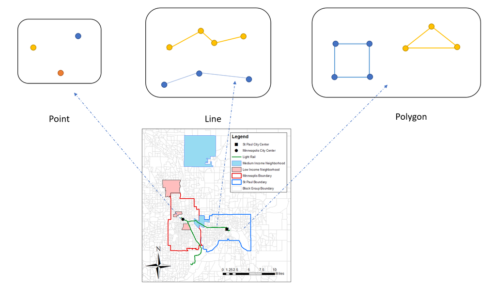

# geometry column

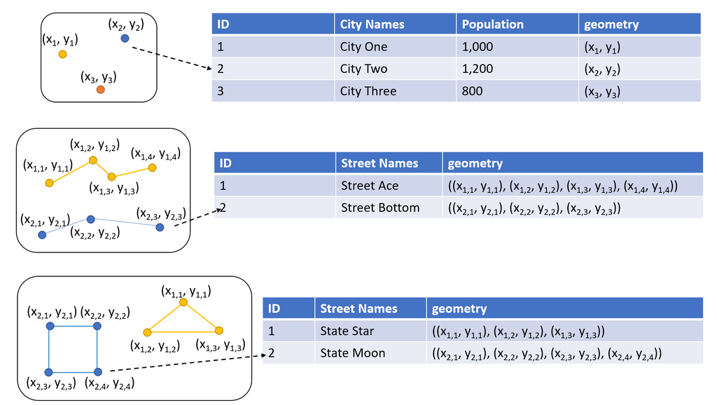

# Coordinate Reference System (CRS)

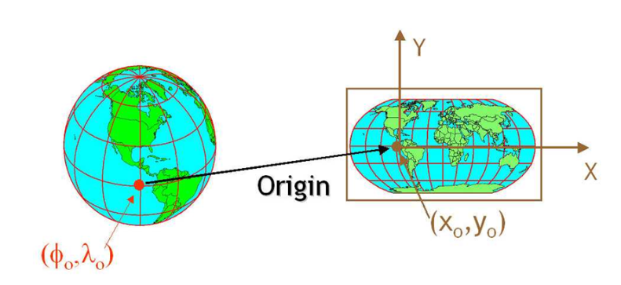

# Coordinate Reference System (CRS)

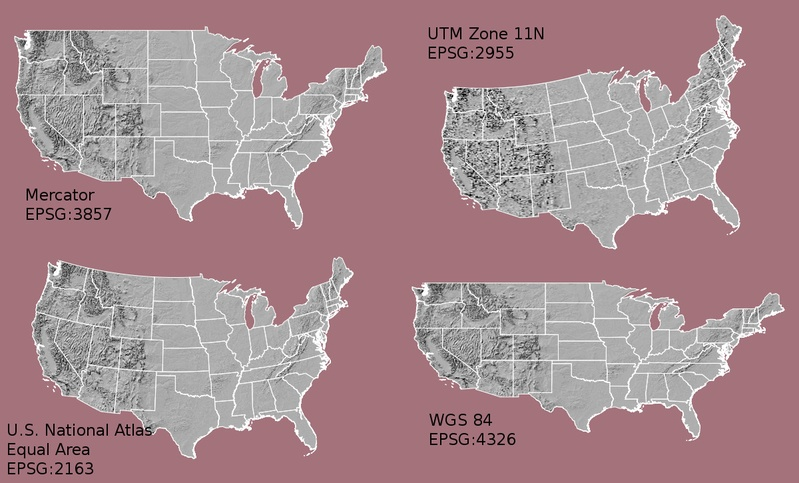

# Preparation before start

We need to install the package.

```r
install.packages('sf')
```

And import the package.

```r
library(sf)
```

# Read files

The file format to store the spatial data is **shapefile**. We could import the shapefile with `st_read()` function into R.

```r
map <- st_read('Census2010RealignTract.shp')
head(map, 3)
```

```
## Simple feature collection with 3 features and 10 fields
## geometry type:  POLYGON
## dimension:      XY
## bbox:           xmin: 448700 ymin: 4924224 xmax: 516478.2 ymax: 4942115
## epsg (SRID):    26915
## proj4string:    +proj=utm +zone=15 +datum=NAD83 +units=m +no_defs
##   TRACT STATE  CO TRACTCE10       GEOID   ALAND10 AWATER10    Acres
## 1 61502    27 037    061502 27037061502 149642919  4668565 38134.50
## 2 61402    27 037    061402 27037061402 211963640  3786753 53258.86
## 3 81200    27 139    081200 27139081200  90667239  3288582 23205.13
##   Shape_Leng Shape_Area                       geometry
## 1   54449.32  154324840 POLYGON ((477636.4 4932330,...
## 2   66036.81  215530975 POLYGON ((496883.5 4929115,...
## 3   38782.40   93907812 POLYGON ((448700 4932487, 4...
```

# CRS of spatial data

We could use `st_crs()` to check the CRS of the variable.

```r
st_crs(map)
```

```
## Coordinate Reference System:
##   EPSG: 26915
##   proj4string: "+proj=utm +zone=15 +datum=NAD83 +units=m +no_defs"
```

Luckily, this spatial dataset contains the right CRS. For the maps in the area of Minnesota, the CRS is the one showing above, 26915 for `EPSG`.

# Assign CRS to spatial data

However, sometimes, the file does not have CRS information. You have to check the original source of the file and assign the right CRS to it.

```r
st_crs(map) <- 26915
```

By doing this, there is a message telling that this function will not do the transformation for us. Sometimes, even if the file contains the right CRS, its CRS might be different from other files.

**If you want to map several spatial datasets in the same page or want to do geospatial data analysis among them, you have to transfer the CRSs of them to the same one. You could do this by using `st_transform()`.**

# Simple spatial visualization with `ggplot2`

We could use `ggplot2` to visualize the map. For simply mapping the polygons, we do not need to speficify `aes()`. And we use `geom_sf()` to plot map.

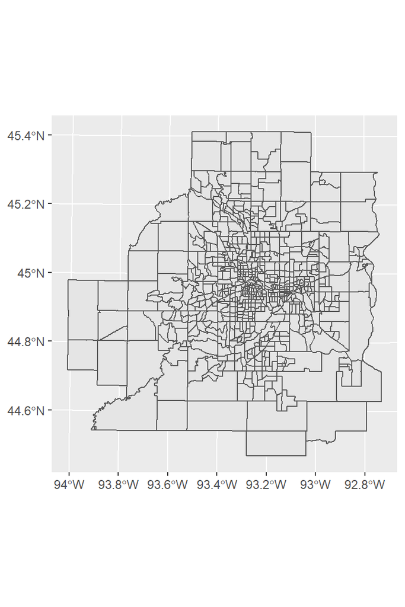

```r
library(ggplot2)
ggplot(map) + geom_sf()
```

# Census system

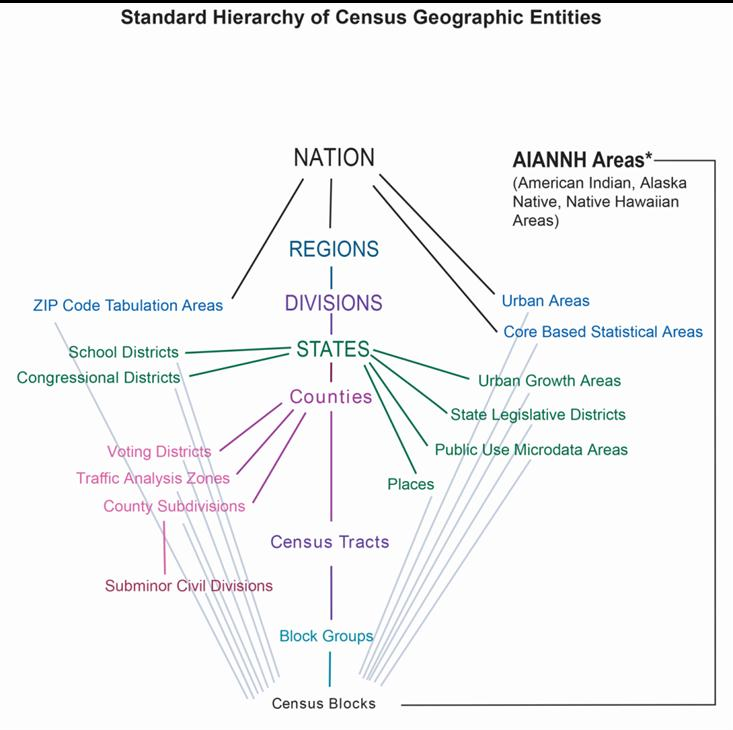

# Census system

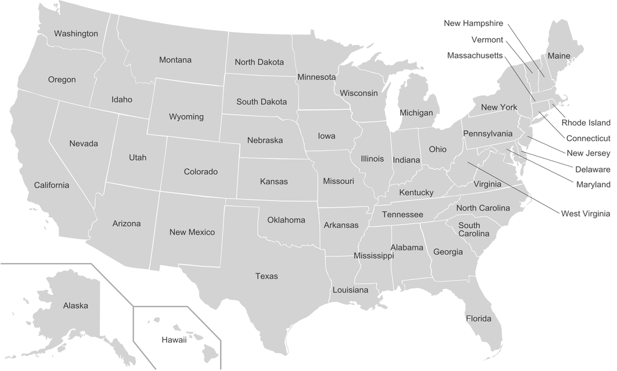

# Census system

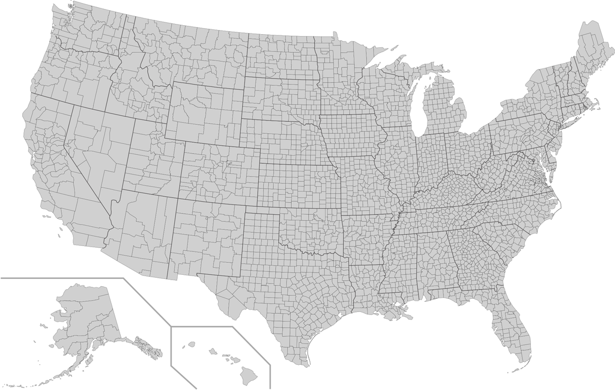

# Census system

The map shows all the census tracts in the Twin Cities metro areas.

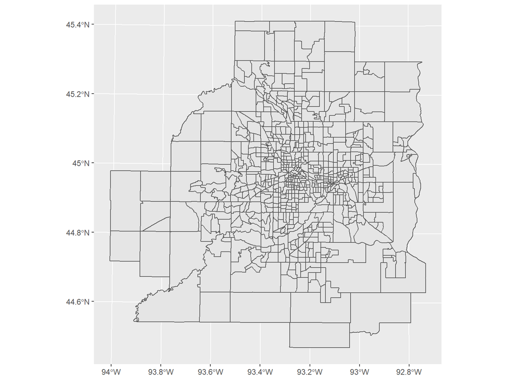

# Deal with R spatial data as a data frame

- Again R spatial data is limilar with data frame except that it has one more column called geometry
- You could use `dplyr` to deal with R spatial data as a data frame

```r
class(map)
```

```
## [1] "sf"         "data.frame"
```

```r
library(dplyr)
new_map <- map %>%
  select(GEOID)
head(new_map, 3)
```

```
## Simple feature collection with 3 features and 1 field
## geometry type:  POLYGON
## dimension:      XY
## bbox:           xmin: 448700 ymin: 4924224 xmax: 516478.2 ymax: 4942115
## epsg (SRID):    26915
## proj4string:    +proj=utm +zone=15 +ellps=GRS80 +towgs84=0,0,0,0,0,0,0 +units=m +no_defs
##         GEOID                       geometry
## 1 27037061502 POLYGON ((477636.4 4932330,...
## 2 27037061402 POLYGON ((496883.5 4929115,...
## 3 27139081200 POLYGON ((448700 4932487, 4...
```

We could join other data to the current geospatial variable by the join functions in `dplyr`. Firstly, we import the data.

```r
library(readr)
data <- read_csv('data.csv')
```

| Variable | Descriptions |
| --- | --- |
| GEOID | Unique identifier used by Census FactFinder website |
| POPTOTAL | Total population |
| HHTOTAL | Total households |
| AGEUNDER18 | Population age under 18 |
| AGE18_39 | Population in this range |
| AGE40_64 | Population in this range |
| AGE65UP | Populationage 65+ |

# Join the the demographic information to the map

Then, we do the join operation.

```r
new_map <- new_map %>%
  left_join(data, by = 'GEOID')
head(new_map, 2)
```

```
## Simple feature collection with 2 features and 7 fields
## geometry type:  POLYGON
## dimension:      XY
## bbox:           xmin: 477595.8 ymin: 4924224 xmax: 516478.2 ymax: 4941888
## epsg (SRID):    26915
## proj4string:    +proj=utm +zone=15 +ellps=GRS80 +towgs84=0,0,0,0,0,0,0 +units=m +no_defs
##         GEOID POPTOTAL HHTOTAL AGEUNDER18 AGE18_39 AGE40_64 AGE65UP
## 1 27037061502     2912    1068        726      549     1094     543
## 2 27037061402     3756    1388        899      937     1444     476
##                         geometry
## 1 POLYGON ((477636.4 4932330,...
## 2 POLYGON ((496883.5 4929115,...
```

# Data management

We calculate the percentage of old people in each census tract.

```r
new_map <- new_map %>%
  mutate(old_percent = AGE65UP/POPTOTAL)
head(new_map, 3)
```

```
## Simple feature collection with 3 features and 8 fields
## geometry type:  POLYGON
## dimension:      XY
## bbox:           xmin: 448700 ymin: 4924224 xmax: 516478.2 ymax: 4942115
## epsg (SRID):    26915
## proj4string:    +proj=utm +zone=15 +ellps=GRS80 +towgs84=0,0,0,0,0,0,0 +units=m +no_defs
##         GEOID POPTOTAL HHTOTAL AGEUNDER18 AGE18_39 AGE40_64 AGE65UP
## 1 27037061502     2912    1068        726      549     1094     543
## 2 27037061402     3756    1388        899      937     1444     476
## 3 27139081200     6297    2193       1737     1571     2190     799
##                         geometry old_percent
## 1 POLYGON ((477636.4 4932330,...   0.1864698
## 2 POLYGON ((496883.5 4929115,...   0.1267306
## 3 POLYGON ((448700 4932487, 4...   0.1268858
```

# Spatial data visualization

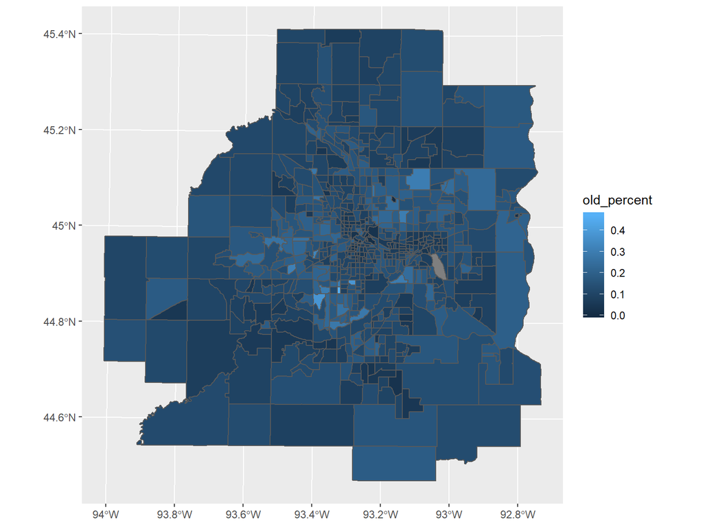

```r
p <- ggplot(new_map, aes(fill = old_percent)) + # use fill to indicate the variable you want to visualize
  geom_sf()
p
```

# Change the color

The color is not good, we could add `scale_fill_gradient()` to specify the colours we want.

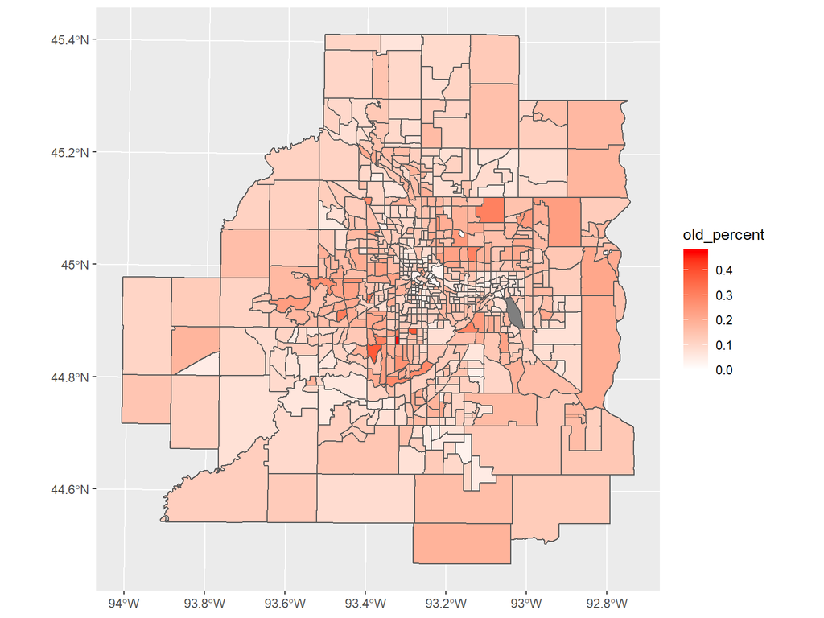

```r
p + scale_fill_gradient(low = 'white', high = 'red')
```

# Add title and theme

Again, we could add more information to make the figure better and more readable, and change the theme a little bit.

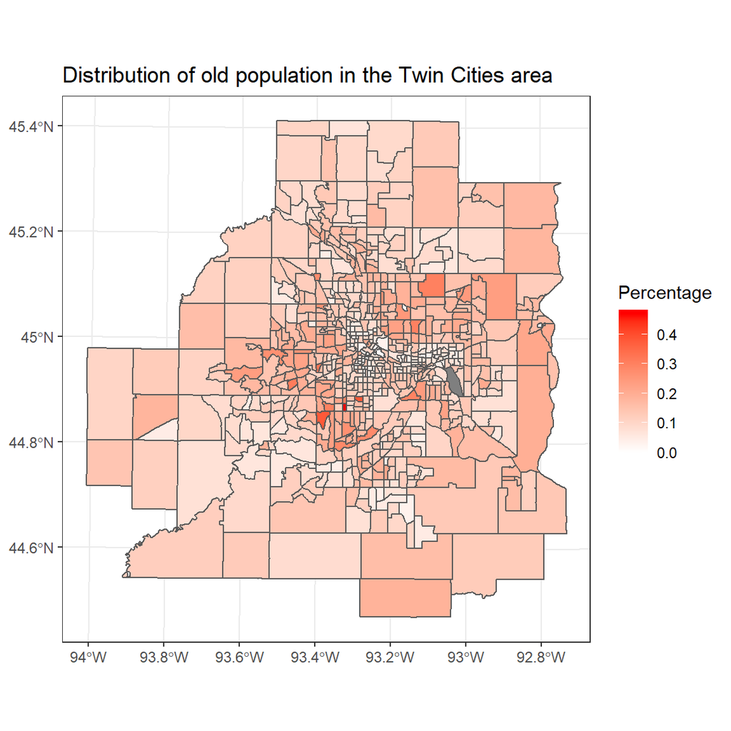

```r
p + scale_fill_gradient(low = 'white', high = 'red') +
  labs(title = 'Distribution of old population in the Twin Cities area',
       fill = 'Percentage') +
  theme_bw()
```

# Save the plot with ggsave()

Finally, we could use `ggsave()` to save the plot we want after we run the `ggplot()` function.

```r
ggsave('fig1.jpg', width = 10, height = 10)
```

# Add other layers in the current plot

```r
transit_route <- st_read('TransitRoutes.shp')
```

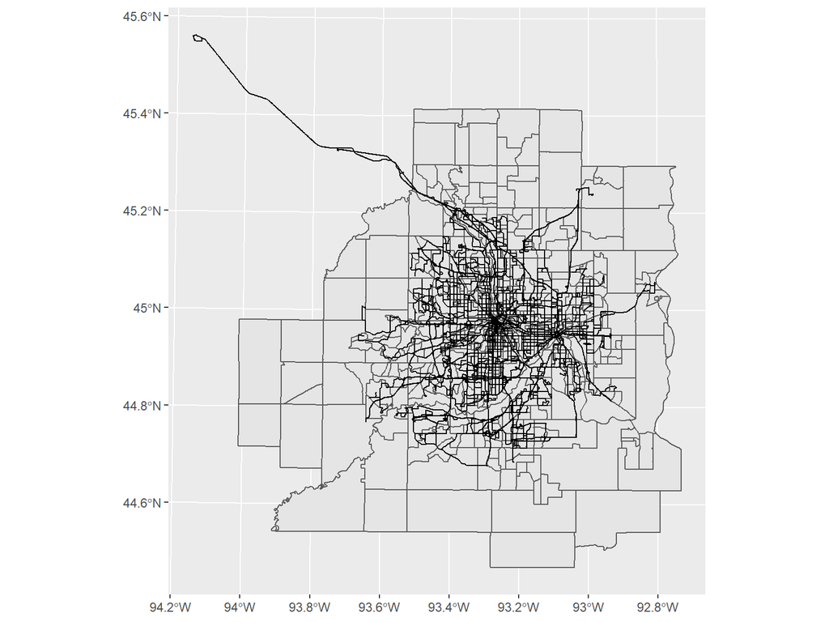

```r
ggplot(new_map) +
  geom_sf() +
  geom_sf(data = transit_route)
```

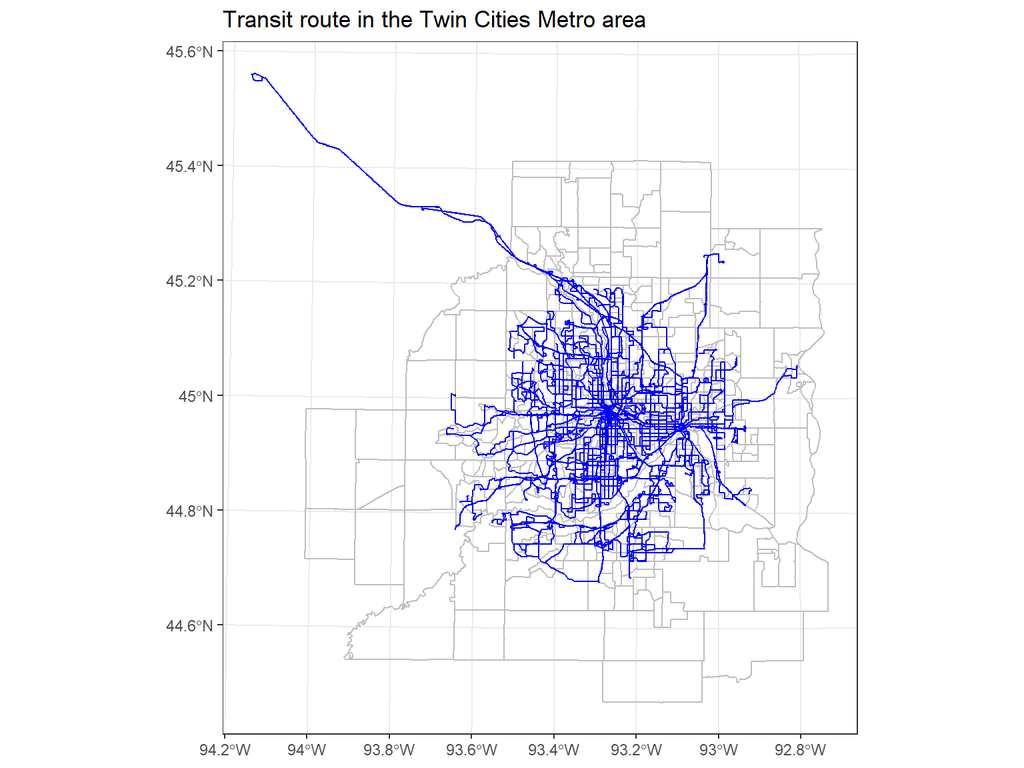

```r
ggplot(new_map) +
  geom_sf(fill = NA, colour = 'Grey') +
  geom_sf(data = transit_route, colour = 'Blue') +
  labs(title = 'Transit route in the Twin Cities Metro area') +
  theme_bw()
```

# Wrap-up for our course

- RStudio and R
- Data management with `dplyr`
- Data visualization with `ggplot2`
- Spatial data visualization
- Statistics
- Data exploratory analysis

# Wrap-up for our course

- Nine in-class exercises
- Final project

# Wrap-up for our course

- The notes for this course will keep online
- Any questions are welcomed even the course is over
- Hope the knowledge you learned from this cource will be helpful during your daily tasks